# Project1

Jenny Norton

9/27/2020

## The Dataset: UFO Sightings Around the World

The data for this project was obtained from https://www.kaggle.com/camnugent/ufo-sightings-around-the-world by Cam Nugent.

## Loading and Cleaning the Data

You can load the clean data here:

```r
source("CleanData.R")
```

```
## here() starts at /Users/hoggard/Google Drive/Classes/Fall 20/DSCI 301/Student submissions/Project1/jnorton11/DSCI301-F20-Project1
```

I read the data into ufo_data and changed the date_documented column from col_character to col_date with the formatting to remove a character at the end.

I had four parsing failures in the length_of_encounter_seconds column and the latitude column but I decided not to fix it at this point.

I tried parsing Date_time to a date and time format but there were 698 parsing failures do to the time being 24:00. Using a str_replace command, I was able to search and replace the 24:00 with 00:00 and parse into the date and time format and add a new column called Date_time2.

I didn’t like how they had the state/province column named so I did a rename command to change it from `state/province` to state_province.

I filtered the data by the Date_time2 column for incidents that happened in the 1970s and arranged by shape and saved it as ufo_data1970 in case I wanted to work with a smaller subset of the data.

## Overview

The data set contains 80,332 entries, dating back to 1949, with 11 original columns:

Date_time - standardized date and time of sighting city - location of UFO sighting state_province - the US state or Canadian province, appears blank for other locations country - Country of UFO sighting UFO_shape - a one word description of the “spacecraft” length_of_encounter_seconds - standardized to seconds, length of the observation of the UFO described_duration _of_encounter - raw description of the length of the encounter description - text description of the UFO encounter date_documented - when was the UFO sighting reported latitude - latitude longitude - longitude

## Summary

The data set contains over 80,000 records of UFO sightings back to 1949. The original file was accessed by Cam Nugent at https://github.com/planetsig/ufo-reports which was prepared by Sigmond Axel in 2014. Sigmond received the data from NUFORC (National UFO Reporting Center) at www.nuforc.org and did a bunch of cleaning of the dates which were using two digit years.

At this point, I’m interested in the UFO_shape and the Date_time2 columns. I might also use the state_province and the country columns after further review and cleaning and the length_of_encounter_seconds column.

## Exploration of the Data

What are the different UFO Shapes?

```r
ufo_data %>%
  count(UFO_shape) %>%
  arrange(desc(n))
```

```
## # A tibble: 30 x 2
##    UFO_shape     n
##    <chr>     <int>
##  1 light     16565
##  2 triangle   7865
##  3 circle     7608
##  4 fireball   6208
##  5 other      5649
##  6 unknown    5584
##  7 sphere     5387
##  8 disk       5213
##  9 oval       3733
## 10 formation  2457
## # … with 20 more rows
```

What states or provinces have the most sightings?

```r
ufo_data %>%
  count(state_province) %>%
  arrange(desc(n))
```

```
## # A tibble: 68 x 2
##    state_province     n
##    <chr>          <int>
##  1 ca              9655
##  2 <NA>            5797
##  3 wa              4268
##  4 fl              4200
##  5 tx              3677
##  6 ny              3219
##  7 az              2689
##  8 il              2645
##  9 pa              2582
## 10 oh              2425
## # … with 58 more rows
```

I see there are quite a few records without a state or province listed so let’s filter those out.

```r
ufo_data %>%
  filter(!is.na(state_province)) %>%
  count(state_province) %>%
  arrange(desc(n))
```

```
## # A tibble: 67 x 2
##    state_province     n
##    <chr>          <int>
##  1 ca              9655
##  2 wa              4268
##  3 fl              4200
##  4 tx              3677
##  5 ny              3219
##  6 az              2689
##  7 il              2645
##  8 pa              2582
##  9 oh              2425
## 10 mi              2071
## # … with 57 more rows
```

Looks like California has the most sightings. I wonder where New Mexico shows up on this list?

```r
ufo_data %>%
  filter(!is.na(state_province), state_province == "nm") %>%
  count(state_province) %>%
  arrange(desc(n))
```

```
## # A tibble: 1 x 2
##   state_province     n
##   <chr>          <int>
## 1 nm               815
```

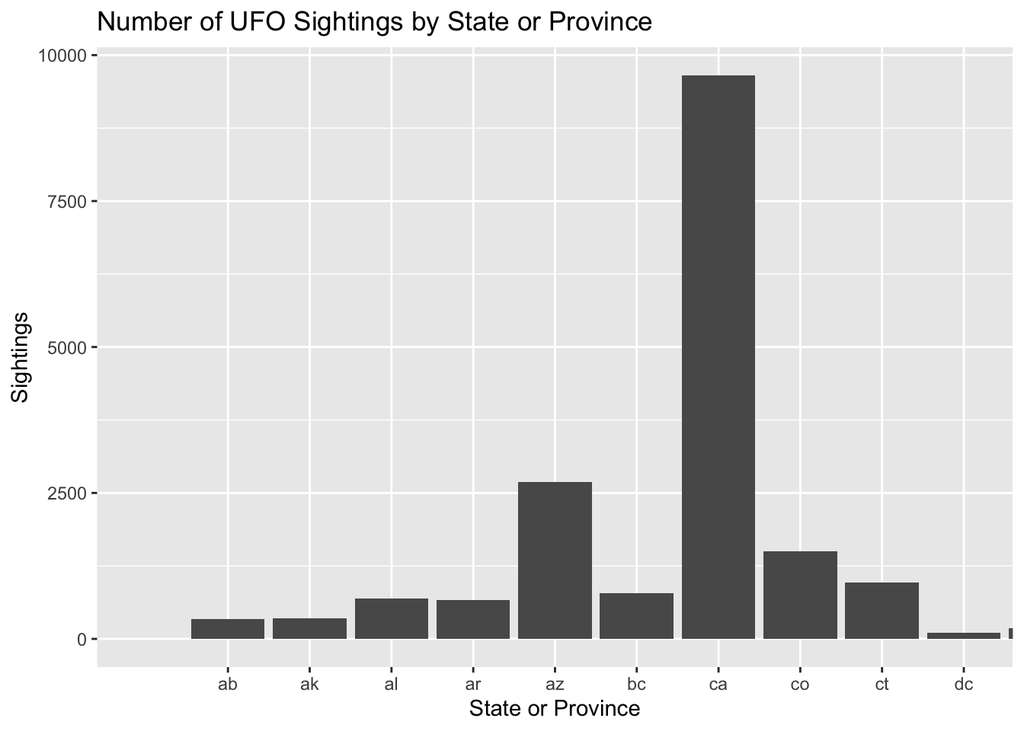

```r
ufo_data %>%
  filter(!is.na(state_province)) %>%
  ggplot() +
  geom_bar(aes(x = state_province)) +
  coord_cartesian(xlim = c(0, 10)) +
  labs(title = "Number of UFO Sightings by State or Province",
       x = "State or Province",
       y = "Sightings")
```

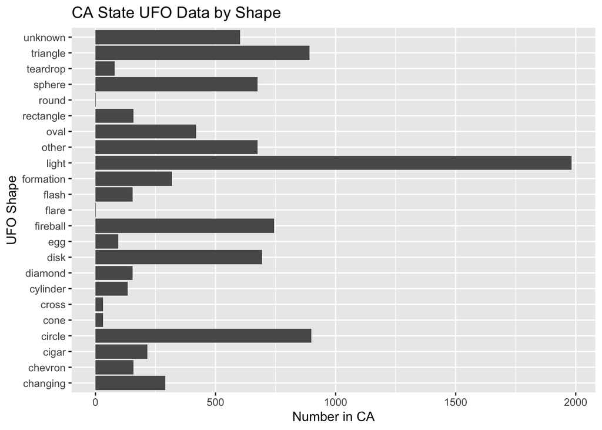

```r
ufo_data %>%
  filter(!is.na(UFO_shape), !is.na(state_province), state_province == "ca") %>%
ggplot() +
      geom_bar(aes(x = UFO_shape)) +
               coord_flip() +
  labs(title = "CA State UFO Data by Shape", x = "UFO Shape", y = "Number in CA")
```

```r
ufo_data %>%
  group_by(UFO_shape) %>%
  mutate(ufo_shape_total = n()) -> ufo_data
```

```r
ufo_data %>%
  summarize(state_province, ufo_shape_total)
```

```
## # A tibble: 80,332 x 3
## # Groups:   UFO_shape [30]
##    UFO_shape state_province ufo_shape_total
##    <chr>     <chr>                    <int>
##  1 changed   co                           1
##  2 changing  ca                        1962
##  3 changing  ca                        1962
##  4 changing  ca                        1962
##  5 changing  mb                        1962
##  6 changing  ga                        1962
##  7 changing  co                        1962
##  8 changing  in                        1962
##  9 changing  fl                        1962
## 10 changing  al                        1962
## # … with 80,322 more rows
```

What are the top 10 states with light sightings?

```r
ufo_data %>%
  filter(!is.na(state_province), UFO_shape == "light") %>%
  count(state_province) %>%
  arrange(desc(n)) %>%
  top_n(10)
```

```
## # A tibble: 10 x 3
## # Groups:   UFO_shape [1]
##    UFO_shape state_province     n
##    <chr>     <chr>          <int>
##  1 light     ca              1983
##  2 light     wa               935
##  3 light     fl               821
##  4 light     tx               745
##  5 light     ny               622
##  6 light     az               613
##  7 light     il               560
##  8 light     pa               514
##  9 light     oh               472
## 10 light     mi               427
```

How can I graph this?

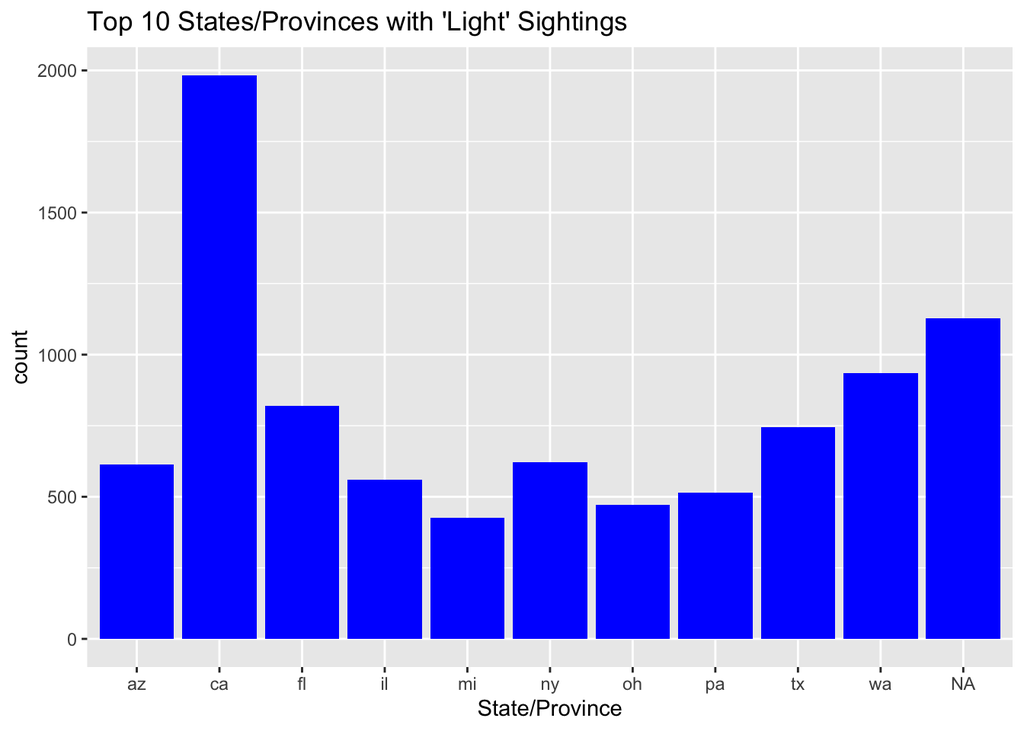

```r
ufo_data %>%
  filter(UFO_shape == "light") %>%
  group_by(state_province) %>%
  filter(n() > 426) %>%
  ungroup() %>%
  ggplot() +
  geom_bar(aes(x = state_province), fill = "blue") +
  labs(title = "Top 10 States/Provinces with 'Light' Sightings",
       x = "State/Province")
```

I wonder why California has so many more light sightings than the other states? The next highest shape is the triangle. I wonder what state has the most sightings of the triangle?

```r
ufo_data %>%
  filter(!is.na(state_province), UFO_shape == "triangle") %>%
  count(state_province) %>%
  arrange(desc(n)) %>%
  top_n(10)
```

```
## # A tibble: 10 x 3
## # Groups:   UFO_shape [1]
##    UFO_shape state_province     n
##    <chr>     <chr>          <int>
##  1 triangle  ca               891
##  2 triangle  fl               385
##  3 triangle  tx               382
##  4 triangle  wa               358
##  5 triangle  il               316
##  6 triangle  ny               314
##  7 triangle  oh               267
##  8 triangle  az               254
##  9 triangle  pa               250
## 10 triangle  mi               239
```

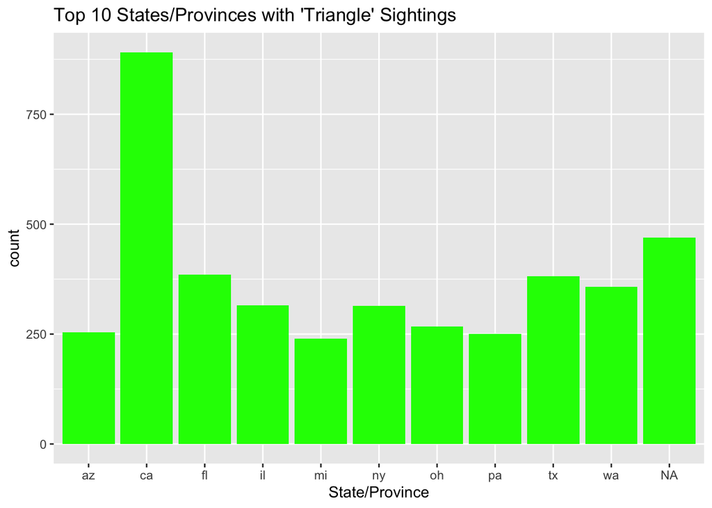

```r
ufo_data %>%
  filter(UFO_shape == "triangle") %>%
  group_by(state_province) %>%
  filter(n() > 238) %>%
  ungroup() %>%
  ggplot() +
  geom_bar(aes(x = state_province), fill = "green") +
  labs(title = "Top 10 States/Provinces with 'Triangle' Sightings",
       x = "State/Province")
```

California again which we should have gathered since California has the most overall sightings.

## Future Work

I would like to keep working with my data and see if I can:

- Determine if the UFO_shape and the length_of_encounter_seconds have any relationship.
- See the top 10 states with overall sightings.
- Calculate the length_of_encounter_seconds into minutes or maybe hours.
- Calculate some averages or medians for the length_of_encounter.
- Make some really cool graphs.

Jenny Norton